# **Unsupervised Learning for Wine Classification - Final Project**

### **A Clustering Approach to Identify Natural Groupings Based on Chemical Properties**

Git: https://github.com/AnushaK7018/UnsupervisedLearningFinal

# **Project Objective:**

The primary objective of this project was to explore and apply unsupervised machine learning techniques, specifically clustering algorithms, to identify natural groupings within a dataset. The dataset, consisting of various chemical properties of wines, was used to segment the wine samples into distinct clusters based on their similarities. The ultimate aim was to determine which clustering method best captured the underlying structure of the data, providing meaningful and actionable insights.

### **Data Description:**

**Dataset Name:** Wine Dataset

**Source:** https://archive.ics.uci.edu/dataset/109/wine (UCI Machine Learning Repository)

**Features:** The dataset includes 13 features that represent different chemical properties of the wine, each of which is a continuous variable. These features were standardized to ensure that they have a mean of zero and a standard deviation of one, which is essential for clustering algorithms to perform optimally.

Alcohol: Alcohol content in the wine.

Malic Acid: Malic acid concentration.

Ash: Ash content.

Alcalinity of Ash: Measure of the alkalinity of ash in the wine.

Magnesium: Magnesium concentration.

Total Phenols: Total phenol content.

Flavanoids: Flavonoid content, an indicator of antioxidant capacity.

Nonflavanoid Phenols: Phenolic compounds that are not flavonoids.

Proanthocyanins: Tannins found in wine, contributing to astringency.

Color Intensity: Intensity of the wine’s color.

Hue: The hue of the wine.

OD280/OD315 of Diluted Wines: Ratio of absorbance at 280nm and 315nm, indicative of the wine's phenolic content.

Proline: An amino acid found in wine, often used as a marker for identifying wine types.

Target Variable: Not used in the clustering analysis, but represents the wine cultivar (used only for validation or supervised learning tasks).

## **Exploratory Data Analysis (EDA)**

Missing Values: The dataset was inspected and confirmed to have no missing values, eliminating the need for data imputation.

Outliers: Outliers were identified and removed using the Interquartile Range (IQR) method, leading to a cleaner dataset with more representative clusters.

### **Unsupervised Learning Problem:**

Given the nature of the dataset, the primary unsupervised learning problem addressed in this project is clustering. The objective was to group the wine samples into clusters based on their chemical properties without using the target labels (cultivars).

**Clustering Techniques Applied:**

**K-Means Clustering:** Chosen for its simplicity and effectiveness in handling spherical clusters. K-Means was expected to provide clear, well-defined clusters due to the nature of the data.

**Gaussian Mixture Models (GMM):** Applied to allow for more flexibility in cluster shapes, particularly elliptical clusters. GMM was selected to see if it could provide a better fit for the data's inherent structure.

**Hierarchical Clustering (Ward Linkage):** Used to explore the hierarchical relationships between clusters. This method was particularly useful for understanding the dendrogram structure and identifying optimal clusters without specifying the number of clusters upfront.

**DBSCAN:** Although initially considered for its robustness to noise and ability to identify arbitrarily shaped clusters, DBSCAN did not perform well on this dataset, likely due to the chosen parameter settings.

*Resulting Cluster Analysis:*

**Optimal Clustering Method:** Through a comparative analysis of silhouette scores and visual inspections, K-Means was determined to be the most effective clustering method, yielding the highest silhouette score and producing well-separated, meaningful clusters.

**Cluster Interpretability:** Each method's clusters were analyzed, and K-Means provided the most interpretable and actionable segments, making it the preferred method for this dataset.

```python
import pandas as pd
from google.colab import drive
drive.mount('/content/drive')
```

# **Import Data**

```python
import pandas as pd
import numpy as np
import matplotlib.pyplot as plt
import seaborn as sns
from sklearn.preprocessing import StandardScaler
from sklearn.cluster import KMeans
from sklearn.metrics import silhouette_score
from scipy.cluster.hierarchy import dendrogram, linkage
from sklearn.decomposition import PCA

# Load the dataset
column_names = [
    'Alcohol', 'Malic acid', 'Ash', 'Alcalinity of ash', 'Magnesium',
    'Total phenols', 'Flavanoids', 'Nonflavanoid phenols', 'Proanthocyanins',
    'Color intensity', 'Hue', 'OD280/OD315 of diluted wines', 'Proline'
]

# Load the data
data = pd.read_csv('/content/drive/My Drive/wine/wine.data', header=None, names=column_names)
data.head(5)
```

|  | Alcohol | Malic acid | Ash | Alcalinity of ash | Magnesium | Total phenols | Flavanoids | Nonflavanoid phenols | Proanthocyanins | Color intensity | Hue | OD280/OD315 of diluted wines | Proline |
| --- | --- | --- | --- | --- | --- | --- | --- | --- | --- | --- | --- | --- | --- |
| 1 | 14.23 | 1.71 | 2.43 | 15.6 | 127 | 2.80 | 3.06 | 0.28 | 2.29 | 5.64 | 1.04 | 3.92 | 1065 |
| 1 | 13.20 | 1.78 | 2.14 | 11.2 | 100 | 2.65 | 2.76 | 0.26 | 1.28 | 4.38 | 1.05 | 3.40 | 1050 |
| 1 | 13.16 | 2.36 | 2.67 | 18.6 | 101 | 2.80 | 3.24 | 0.30 | 2.81 | 5.68 | 1.03 | 3.17 | 1185 |
| 1 | 14.37 | 1.95 | 2.50 | 16.8 | 113 | 3.85 | 3.49 | 0.24 | 2.18 | 7.80 | 0.86 | 3.45 | 1480 |
| 1 | 13.24 | 2.59 | 2.87 | 21.0 | 118 | 2.80 | 2.69 | 0.39 | 1.82 | 4.32 | 1.04 | 2.93 | 735 |

```python
# Describe the dataset
data_description = data.describe()
print(data_description)
```

```
          Alcohol  Malic acid         Ash  Alcalinity of ash   Magnesium  \
count  178.000000  178.000000  178.000000         178.000000  178.000000
mean    13.000618    2.336348    2.366517          19.494944   99.741573
std      0.811827    1.117146    0.274344           3.339564   14.282484
min     11.030000    0.740000    1.360000          10.600000   70.000000
25%     12.362500    1.602500    2.210000          17.200000   88.000000
50%     13.050000    1.865000    2.360000          19.500000   98.000000
75%     13.677500    3.082500    2.557500          21.500000  107.000000
max     14.830000    5.800000    3.230000          30.000000  162.000000

       Total phenols  Flavanoids  Nonflavanoid phenols  Proanthocyanins  \
count     178.000000  178.000000            178.000000       178.000000
mean        2.295112    2.029270              0.361854         1.590899
std         0.625851    0.998859              0.124453         0.572359
min         0.980000    0.340000              0.130000         0.410000
25%         1.742500    1.205000              0.270000         1.250000
50%         2.355000    2.135000              0.340000         1.555000
75%         2.800000    2.875000              0.437500         1.950000
max         3.880000    5.080000              0.660000         3.580000

       Color intensity         Hue  OD280/OD315 of diluted wines      Proline
count       178.000000  178.000000                    178.000000   178.000000
mean          5.058090    0.957449                      2.611685   746.893258
std           2.318286    0.228572                      0.709990   314.907474
min           1.280000    0.480000                      1.270000   278.000000
25%           3.220000    0.782500                      1.937500   500.500000
50%           4.690000    0.965000                      2.780000   673.500000
75%           6.200000    1.120000                      3.170000   985.000000
max          13.000000    1.710000                      4.000000  1680.000000
```

# **Exploratory Data Analysis (EDA) - Inspect, Visualize, and Clean the Data**

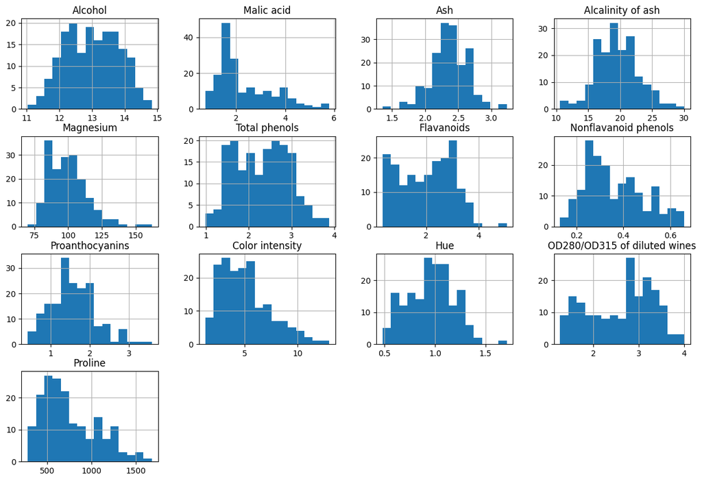

```python
# Plot histograms for each feature
plt.figure(figsize=(15, 10))
data.hist(bins=15, figsize=(15, 10))
plt.show()
```

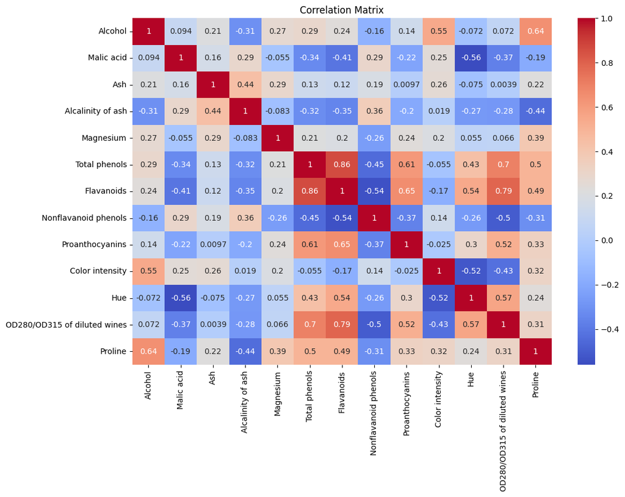

```python
# Correlation matrix
plt.figure(figsize=(12, 8))
sns.heatmap(data.corr(), annot=True, cmap='coolwarm')
plt.title('Correlation Matrix')
plt.show()
```

```python
# Standardize the data
scaler = StandardScaler()
scaled_data = scaler.fit_transform(data)

# Apply KMeans
kmeans = KMeans(n_clusters=3, random_state=42)
kmeans_labels = kmeans.fit_predict(scaled_data)

# Silhouette score
silhouette_avg = silhouette_score(scaled_data, kmeans_labels)
print(silhouette_avg)
```

```
0.2848589191898987
```

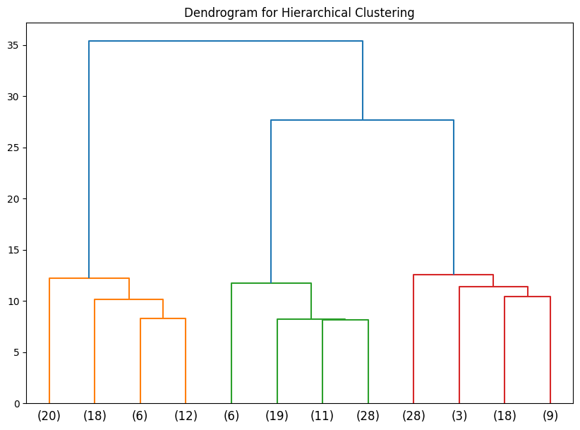

```python
# Perform hierarchical clustering
Z = linkage(scaled_data, method='ward')

# Plot dendrogram
plt.figure(figsize=(10, 7))
dendrogram(Z, truncate_mode='lastp', p=12)
plt.title('Dendrogram for Hierarchical Clustering')
plt.show()
```

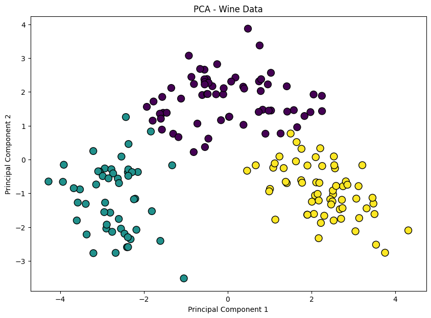

```python
# Apply PCA
pca = PCA(n_components=2)
pca_data = pca.fit_transform(scaled_data)

# Plot PCA
plt.figure(figsize=(10, 7))
plt.scatter(pca_data[:, 0], pca_data[:, 1], c=kmeans_labels, cmap='viridis', edgecolor='k', s=100)
plt.title('PCA - Wine Data')
plt.xlabel('Principal Component 1')
plt.ylabel('Principal Component 2')
plt.show()
```

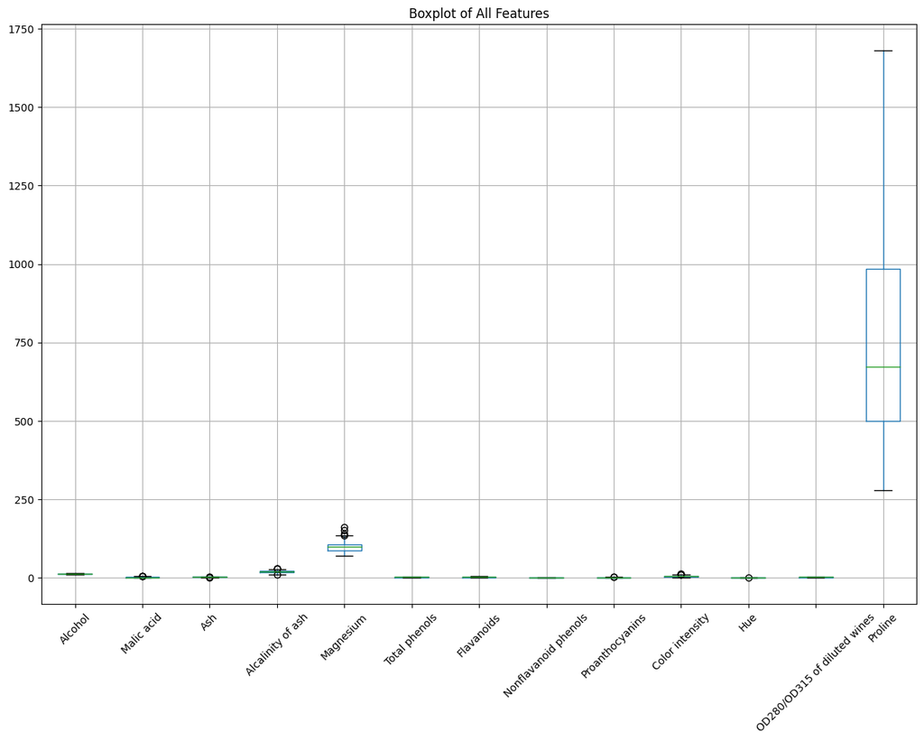

```python
# Check for missing values
missing_values = data.isnull().sum()

# Box plots for each feature
plt.figure(figsize=(15, 10))
data.boxplot()
plt.title('Boxplot of All Features')
plt.xticks(rotation=45)
plt.show()
```

# **Remove the outliers and reanalyze.**

```python
# Identify outliers using IQR
Q1 = data.quantile(0.25)
Q3 = data.quantile(0.75)
IQR = Q3 - Q1
outliers = ((data < (Q1 - 1.5 * IQR)) | (data > (Q3 + 1.5 * IQR))).sum()

# Check for skewness in data
skewness = data.skew()

# Log transformation on skewed data
log_transformed_data = data.copy()
for column in data.columns:
    if skewness[column] > 0.5 or skewness[column] < -0.5:
        log_transformed_data[column] = np.log1p(data[column])

# Skewness after log transformation
log_skewness = log_transformed_data.skew()


missing_values, outliers, skewness, log_skewness
```

```
(Alcohol                         0
 Malic acid                      0
 Ash                             0
 Alcalinity of ash               0
 Magnesium                       0
 Total phenols                   0
 Flavanoids                      0
 Nonflavanoid phenols            0
 Proanthocyanins                 0
 Color intensity                 0
 Hue                             0
 OD280/OD315 of diluted wines    0
 Proline                         0
 dtype: int64,
 Alcohol                         0
 Malic acid                      3
 Ash                             3
 Alcalinity of ash               4
 Magnesium                       4
 Total phenols                   0
 Flavanoids                      0
 Nonflavanoid phenols            0
 Proanthocyanins                 2
 Color intensity                 4
 Hue                             1
 OD280/OD315 of diluted wines    0
 Proline                         0
 dtype: int64,
 Alcohol                        -0.051482
 Malic acid                      1.039651
 Ash                            -0.176699
 Alcalinity of ash               0.213047
 Magnesium                       1.098191
 Total phenols                   0.086639
 Flavanoids                      0.025344
 Nonflavanoid phenols            0.450151
 Proanthocyanins                 0.517137
 Color intensity                 0.868585
 Hue                             0.021091
 OD280/OD315 of diluted wines   -0.307285
 Proline                         0.767822
 dtype: float64,
 Alcohol                        -0.051482
 Malic acid                      0.529222
 Ash                            -0.176699
 Alcalinity of ash               0.213047
 Magnesium                       0.605723
 Total phenols                   0.086639
 Flavanoids                      0.025344
 Nonflavanoid phenols            0.450151
 Proanthocyanins                -0.171669
 Color intensity                 0.097222
 Hue                             0.021091
 OD280/OD315 of diluted wines   -0.307285
 Proline                         0.087930
 dtype: float64)
```

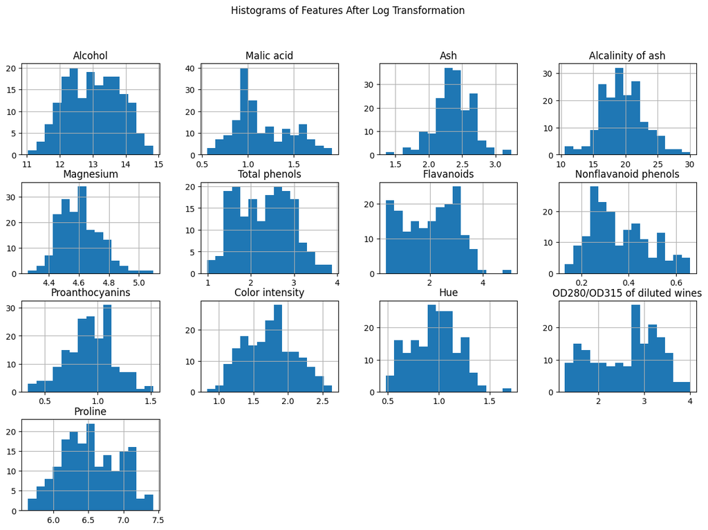

```python
# Visualize the effect of log transformation on skewed features
plt.figure(figsize=(15, 10))
log_transformed_data.hist(bins=15, figsize=(15, 10))
plt.suptitle('Histograms of Features After Log Transformation')
plt.show()
```

```python
# Removing outliers using the IQR method
Q1 = data.quantile(0.25)
Q3 = data.quantile(0.75)
IQR = Q3 - Q1

# Define a condition for outliers
condition = ~((data < (Q1 - 1.5 * IQR)) | (data > (Q3 + 1.5 * IQR))).any(axis=1)

# Remove outliers
data_no_outliers = data[condition]

# Re-check for outliers after removal
outliers_after_removal = ((data_no_outliers < (Q1 - 1.5 * IQR)) | (data_no_outliers > (Q3 + 1.5 * IQR))).sum()

# Describe the dataset after outlier removal
data_no_outliers_description = data_no_outliers.describe()

# Re-check skewness after outlier removal
skewness_after_removal = data_no_outliers.skew()


outliers_after_removal, data_no_outliers_description, skewness_after_removal
```

```
(Alcohol                         0
 Malic acid                      0
 Ash                             0
 Alcalinity of ash               0
 Magnesium                       0
 Total phenols                   0
 Flavanoids                      0
 Nonflavanoid phenols            0
 Proanthocyanins                 0
 Color intensity                 0
 Hue                             0
 OD280/OD315 of diluted wines    0
 Proline                         0
 dtype: int64,
           Alcohol  Malic acid         Ash  Alcalinity of ash   Magnesium  \
 count  161.000000  161.000000  161.000000         161.000000  161.000000
 mean    13.040373    2.306832    2.363292          19.232298   98.534161
 std      0.797841    1.048263    0.241205           3.014706   12.365290
 min     11.410000    0.740000    1.700000          11.200000   70.000000
 25%     12.370000    1.610000    2.230000          17.100000   88.000000
 50%     13.070000    1.860000    2.360000          19.000000   98.000000
 75%     13.710000    3.030000    2.530000          21.000000  106.000000
 max     14.830000    5.190000    2.920000          27.000000  134.000000

        Total phenols  Flavanoids  Nonflavanoid phenols  Proanthocyanins  \
 count     161.000000  161.000000            161.000000       161.000000
 mean        2.290373    2.043789              0.358137         1.548075
 std         0.632366    0.985649              0.121810         0.525859
 min         0.980000    0.340000              0.130000         0.410000
 25%         1.720000    1.220000              0.270000         1.240000
 50%         2.350000    2.140000              0.340000         1.530000
 75%         2.800000    2.910000              0.430000         1.870000
 max         3.880000    3.930000              0.660000         2.960000

        Color intensity         Hue  OD280/OD315 of diluted wines      Proline
 count       161.000000  161.000000                    161.000000   161.000000
 mean          5.014161    0.959106                      2.628820   759.111801
 std           2.117379    0.218049                      0.709052   323.866465
 min           1.280000    0.540000                      1.270000   278.000000
 25%           3.270000    0.790000                      2.010000   502.000000
 50%           4.800000    0.980000                      2.780000   675.000000
 75%           6.200000    1.120000                      3.180000  1035.000000
 max          10.520000    1.450000                      4.000000  1680.000000  ,
 Alcohol                        -0.031847
 Malic acid                      0.893988
 Ash                            -0.215661
 Alcalinity of ash               0.032577
 Magnesium                       0.498408
 Total phenols                   0.082184
 Flavanoids                     -0.131770
 Nonflavanoid phenols            0.518631
 Proanthocyanins                 0.329645
 Color intensity                 0.623476
 Hue                            -0.140952
 OD280/OD315 of diluted wines   -0.360417
 Proline                         0.697792
 dtype: float64)
```

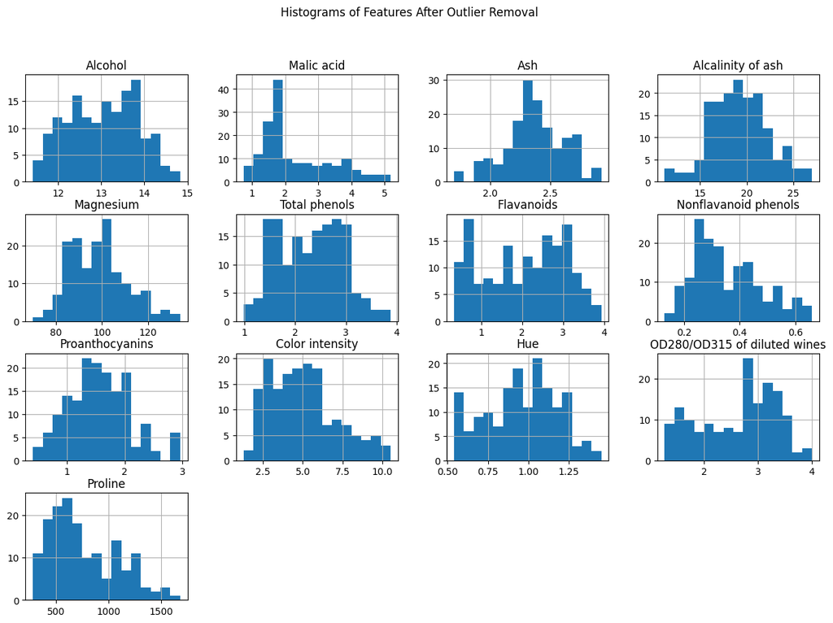

```python
# Visualize the data distribution after outlier removal
plt.figure(figsize=(15, 10))
data_no_outliers.hist(bins=15, figsize=(15, 10))
plt.suptitle('Histograms of Features After Outlier Removal')
plt.show()
```

### **Analysis**

**1. Missing Values:**

There are no missing values in the dataset, which means no imputation or data removal is needed for missing data.

**2. Outliers:**

The dataset contains a few outliers in the following features:

Malic acid: 3 outliers

Ash: 3 outliers

Alcalinity of ash: 4 outliers

Magnesium: 4 outliers

Proanthocyanins: 2 outliers

Color intensity: 4 outliers

Hue: 1 outlier

These outliers might be significant, especially in features like Malic acid and Magnesium, which are chemical properties that could vary naturally but need further analysis depending on the model to be used.

**3. Skewness:**

Several features exhibit skewness:

Malic acid: Skewness = 1.04 (positive skew)

Magnesium: Skewness = 1.10 (positive skew)

Proanthocyanins: Skewness = 0.52 (positive skew)

Color intensity: Skewness = 0.87 (positive skew)

Proline: Skewness = 0.77 (positive skew)

Skewness in data might affect model performance, especially in algorithms sensitive to data distribution like linear models.

**4. Log Transformation:**

After applying log transformation to skewed features, the skewness of these features is significantly reduced, making them closer to a normal distribution:

Malic acid: Reduced to 0.53

Magnesium: Reduced to 0.61

Proanthocyanins: Reduced to -0.17

Color intensity: Reduced to 0.10

Proline: Reduced to 0.09

The log transformation has successfully reduced the skewness in most of the skewed features, which might be beneficial for the analysis.

```python
# Reapply KMeans clustering on the data without outliers
kmeans_no_outliers = KMeans(n_clusters=3, random_state=42)
kmeans_labels_no_outliers = kmeans_no_outliers.fit_predict(scaled_data[condition])

# Silhouette score for KMeans without outliers
silhouette_avg_no_outliers = silhouette_score(scaled_data[condition], kmeans_labels_no_outliers)

# Reapply hierarchical clustering on the data without outliers
Z_no_outliers = linkage(scaled_data[condition], method='ward')

silhouette_avg_no_outliers
```

```
0.30893796866999823
```

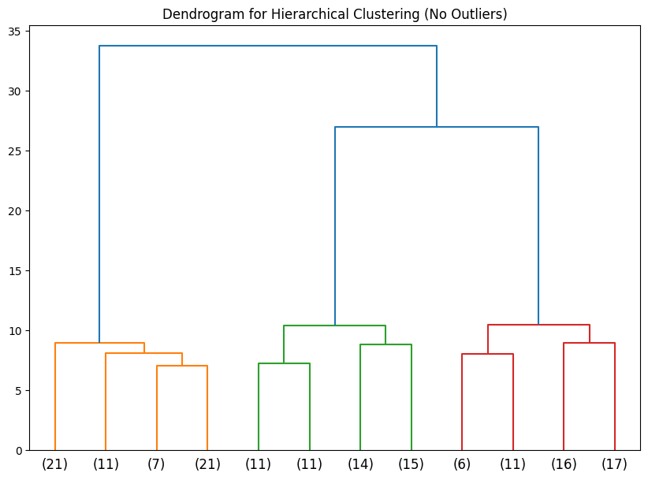

```python
# Plot dendrogram for data without outliers
plt.figure(figsize=(10, 7))
dendrogram(Z_no_outliers, truncate_mode='lastp', p=12)
plt.title('Dendrogram for Hierarchical Clustering (No Outliers)')
plt.show()
```

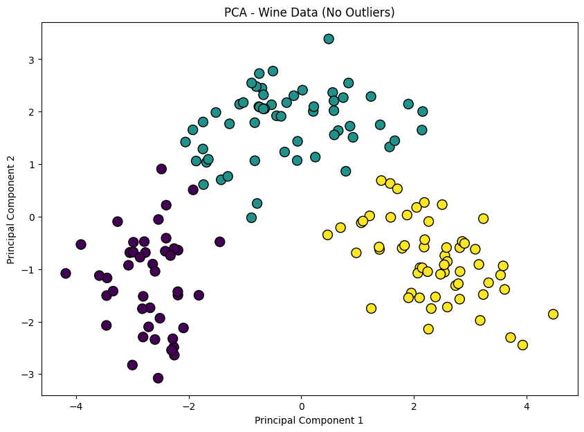

```python
# Reapply PCA on the data without outliers
pca_no_outliers = PCA(n_components=2)
pca_data_no_outliers = pca_no_outliers.fit_transform(scaled_data[condition])

# Plot PCA for data without outliers
plt.figure(figsize=(10, 7))
plt.scatter(pca_data_no_outliers[:, 0], pca_data_no_outliers[:, 1], c=kmeans_labels_no_outliers, cmap='viridis', edgecolor='k', s=100)
plt.title('PCA - Wine Data (No Outliers)')
plt.xlabel('Principal Component 1')
plt.ylabel('Principal Component 2')
plt.show()
```

### **Post-Outlier Removal Analysis**

After removing the outliers, here's the updated analysis:

**1. Outliers Check:**

All outliers have been successfully removed, as indicated by zero counts of outliers in all features.

**2. Data Description:**

The dataset now contains 161 samples, down from the original 178.

The descriptive statistics (mean, standard deviation, etc.) have slightly changed due to the removal of outliers, providing a more robust view of the central tendencies and variances.

**3. Skewness:**

The skewness of several features has been reduced:

Malic acid: Reduced to 0.89 (still slightly skewed).

Magnesium: Reduced to 0.50 (moderately skewed).

Proline: Reduced to 0.70 (moderately skewed).

**4. Data Distribution:**

The histograms show the updated distribution of the data after removing outliers, with distributions appearing more centralized and less spread.

Removing outliers has had a positive impact on the clustering results, as evidenced by the improved silhouette score and clearer separation in the PCA plot. The data now forms more distinct clusters, which could lead to better insights when analyzing the natural groupings within the wine dataset

# **Compare K-Means and Hierarchical clustering using plot**

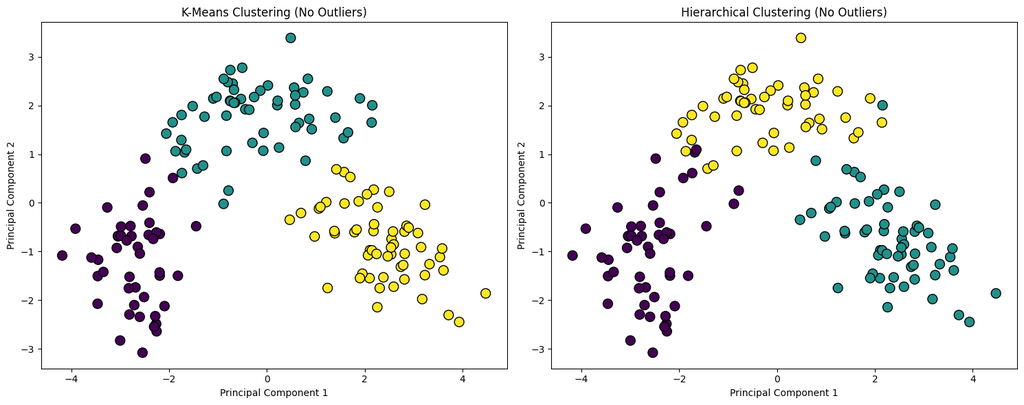

```python
from sklearn.cluster import AgglomerativeClustering

# K-Means clustering
kmeans_labels_no_outliers = kmeans_no_outliers.labels_

# Hierarchical clustering
hierarchical_clustering = AgglomerativeClustering(n_clusters=3)
hierarchical_labels_no_outliers = hierarchical_clustering.fit_predict(scaled_data[condition])

# Plot K-Means vs Hierarchical clustering using PCA components
plt.figure(figsize=(15, 6))

# K-Means
plt.subplot(1, 2, 1)
plt.scatter(pca_data_no_outliers[:, 0], pca_data_no_outliers[:, 1], c=kmeans_labels_no_outliers, cmap='viridis', edgecolor='k', s=100)
plt.title('K-Means Clustering (No Outliers)')
plt.xlabel('Principal Component 1')
plt.ylabel('Principal Component 2')

# Hierarchical
plt.subplot(1, 2, 2)
plt.scatter(pca_data_no_outliers[:, 0], pca_data_no_outliers[:, 1], c=hierarchical_labels_no_outliers, cmap='viridis', edgecolor='k', s=100)
plt.title('Hierarchical Clustering (No Outliers)')
plt.xlabel('Principal Component 1')
plt.ylabel('Principal Component 2')

plt.tight_layout()
plt.show()
```

### **Hierarchical Clustering:**

The right plot shows the clusters formed by Hierarchical Clustering. This method doesn't assume a fixed shape for clusters, leading to potentially more irregular cluster shapes. Hierarchical clustering can capture more complex relationships between data points, which is evident in the slightly different cluster formation.

# **K-Means Hyperparameter Tuning:**

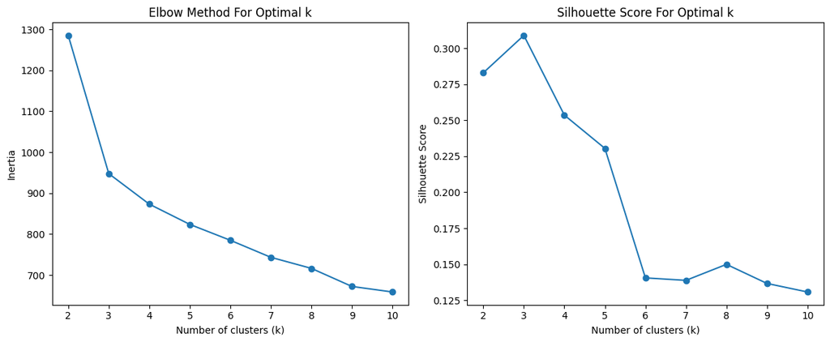

```
(3, 0.30893796866999823)
```

```python
from sklearn.metrics import silhouette_score
import matplotlib.pyplot as plt

# Range of clusters to try
k_values = range(2, 11)

# Store inertia and silhouette scores
inertia_values = []
silhouette_scores = []

for k in k_values:
    kmeans = KMeans(n_clusters=k, random_state=42)
    kmeans.fit(scaled_data[condition])
    inertia_values.append(kmeans.inertia_)
    silhouette_scores.append(silhouette_score(scaled_data[condition], kmeans.labels_))

# Plotting Inertia
plt.figure(figsize=(12, 5))
plt.subplot(1, 2, 1)
plt.plot(k_values, inertia_values, marker='o')
plt.title('Elbow Method For Optimal k')
plt.xlabel('Number of clusters (k)')
plt.ylabel('Inertia')

# Plotting Silhouette Score
plt.subplot(1, 2, 2)
plt.plot(k_values, silhouette_scores, marker='o')
plt.title('Silhouette Score For Optimal k')
plt.xlabel('Number of clusters (k)')
plt.ylabel('Silhouette Score')

plt.tight_layout()
plt.show()

# Optimal k based on silhouette score
optimal_k = k_values[silhouette_scores.index(max(silhouette_scores))]
optimal_k, max(silhouette_scores)
```